# MEML_HW5_Solution

**Machine Learning for Mechanical Engineering**  
**Homework 05**  
**Due Thursday, 05/09/2019, 9:30 AM**

By Prof. Seungchul Lee  
http://iai.postech.ac.kr/  
Industrial AI Lab at POSTECH

- For your handwritten solution, hand in your hardcopy before the class begins.
- For your code, email your .ipynb file to iai.postech@gmail.com. Only .ipynb file will be graded.
- When you send an e-mail, write down [Machine Learning Homework] on the title
- And please write your NAME on your .ipynb files. ex) 이남정_20192319 _HW1.ipynb
- Do not submit a printed version of your code. It will not be graded.
- If you have any questions on the homework problems, please email our TA via iai.postech@gmail.com.

# Problem 1

Download this data [reg_pca_data](https://www.dropbox.com/sh/n56f2y2vo9t876l/AADExG_yeB-druiUAQgSXo-za?dl=1)

```python
from six.moves import cPickle

x_reg = cPickle.load(open('./image_files/x_reg.pkl', 'rb'))
y_reg = cPickle.load(open('./image_files/y_reg.pkl', 'rb'))
```

1) Write a python code to conduct a linear regression (least square).

```python
## your code here
```

2) Write a python code to perform PCA. Since `mean(x) = mean(y) = 0`, normalization step (mean subtraction and rescaling) can be skipped.

```python
## your code here
```

3) Comment on why the results are different as shown in Figure 6?

[figure not shown]

Figure 6

```python
## your code here
```

# Solution 1

Download this data [reg_pca_data](https://www.dropbox.com/sh/n56f2y2vo9t876l/AADExG_yeB-druiUAQgSXo-za?dl=1)

```python
from six.moves import cPickle
import matplotlib.pyplot as plt
import cvxpy as cvx
import numpy as np

x_reg = cPickle.load(open('./image_files/x_reg.pkl', 'rb'))
y_reg = cPickle.load(open('./image_files/y_reg.pkl', 'rb'))
```

1) Write a python code to conduct a linear regression (least square).

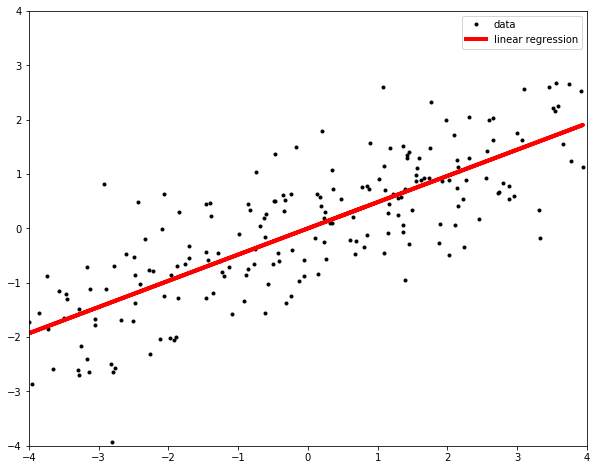

```python
x_reg = x_reg.reshape(-1, 1)
y_reg = y_reg.reshape(-1, 1)
ones_col = np.ones((x_reg.size, 1))
phi = np.hstack([x_reg, ones_col])

w = cvx.Variable(2)
objective = cvx.Minimize(cvx.sum_squares(phi * w - y_reg))
prob = cvx.Problem(objective)
prob.solve()
w = w.value

plt.figure(figsize = (10, 8))
plt.plot(x_reg, y_reg, 'k.', label = 'data')
plt.plot(x_reg, x_reg * w[0] + np.ones((200, 1)) * w[1], color = 'red', label = 'linear regression', linewidth = 4.0)
plt.xlim(-4,4)
plt.ylim(-4,4)
plt.legend()
plt.show()
```

2) Write a python code to perform PCA. Since `mean(x) = mean(y) = 0`, normalization step (mean subtraction and rescaling) can be skipped.

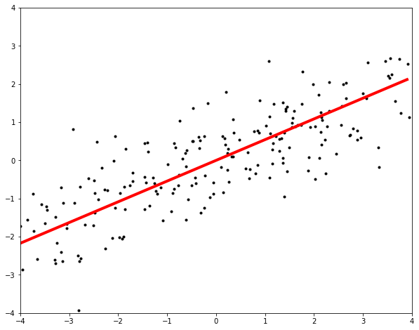

```python
num_data = x_reg.size
data = np.hstack([x_reg, y_reg])
data = np.asmatrix(data)
S = 1 / (num_data - 1) * data.T * data

D, V = np.linalg.eig(S)
idx = np.argsort(-D)
D = D[idx]; V = V[:, idx]
h = V[1, 0] / V[0, 0]
xp = np.arange(-4, 4, 0.1)
yp = h * xp;

plt.figure(figsize = (10, 8))
plt.plot(x_reg, y_reg, 'k.')
plt.plot(xp, yp, 'r', linewidth = 4.0)
plt.xlim(-4,4)
plt.ylim(-4,4)
plt.show()
```

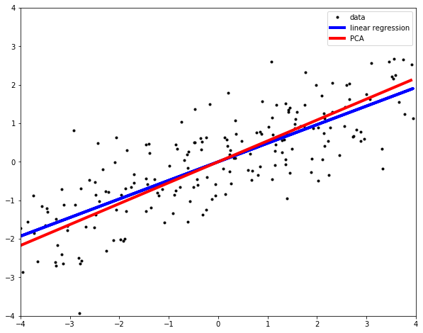

```python
fig = plt.figure(figsize=(10, 8))
plt.plot(x_reg, y_reg, 'k.', label = 'data')
plt.plot(x_reg, x_reg * w[0] + np.ones((200, 1)) * w[1], 'b', linewidth = 4.0, label = 'linear regression')
plt.plot(xp, yp, 'r', linewidth = 4.0, label = 'PCA')
plt.xlim(-4,4)
plt.ylim(-4,4)
plt.legend()
plt.show()
```

3) Comment on why the results are different as shown in Figure 6?

[figure not shown]

Figure 6

# Problem 2

1) Solve the problem with Fisher Discriminant Analysis and plot the projection line.

```python
import numpy as np
import random
import matplotlib.pyplot as plt

%matplotlib inline
```

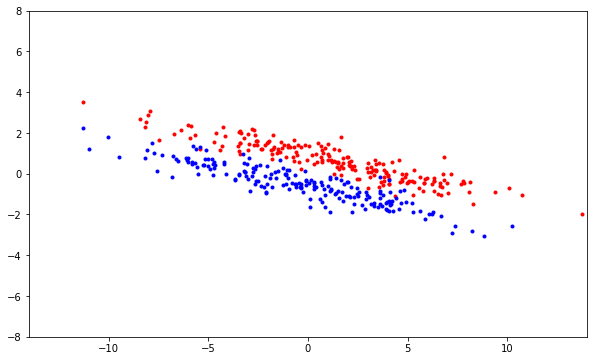

```python
n0 = 200
n1 = 200

sigma = [[19, -4],
         [-4, 1]]

x0 = np.random.multivariate_normal([0.7,0.7], sigma, n0)        # data in class 0
x1 = np.random.multivariate_normal([-0.5,-0.5], sigma, n1)      # data in class 0

x0 = np.asmatrix(x0)
x1 = np.asmatrix(x1)

plt.figure(figsize = (10, 6))
plt.plot(x0[:,0],x0[:,1],'r.')
plt.plot(x1[:,0],x1[:,1],'b.')
plt.ylim([-8, 8])
plt.xlim([-14, 14])
plt.show()
```

```python
#your code here
```

2) Solve the above problem with PCA and plot the projection line. In the case of PCA, you do not need to consider labels.(*i.e.* data class)

```python
## your code here
```

# Solution 2

1) Solve the problem with Fisher Discriminant Analysis and plot the projection line.

```python
import random

%matplotlib inline
```

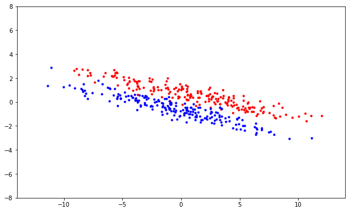

```python
n0 = 200
n1 = 200

sigma = [[19, -4],
         [-4, 1]]

x0 = np.random.multivariate_normal([0.7,0.7], sigma, n0)        # data in class 0
x1 = np.random.multivariate_normal([-0.5,-0.5], sigma, n1)      # data in class 0

x0 = np.asmatrix(x0)
x1 = np.asmatrix(x1)

plt.figure(figsize = (10, 6))
plt.plot(x0[:,0],x0[:,1],'r.')
plt.plot(x1[:,0],x1[:,1],'b.')
plt.ylim([-8, 8])
plt.xlim([-14, 14])
plt.show()
```

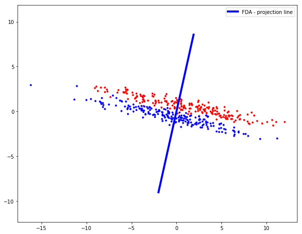

```python
x0 = np.asmatrix(x0)
x1 = np.asmatrix(x1)

mu0 = np.mean(x0, axis = 0)
mu1 = np.mean(x1, axis = 0)
S0 = 1 / (n0 - 1) * (x0 - mu0).T * (x0 - mu0)
S1 = 1 / (n1 - 1) * (x1 - mu1).T * (x1 - mu1)

w = (n0 * S0 + n1 * S1).I * (mu0 - mu1).T
h = w[1] / w[0]
xp = np.arange(-2, 2, 0.1)
yp = (h * xp).reshape(-1, 1)

plt.figure(figsize = (10, 8))
plt.plot(x0[:,0],x0[:,1],'r.')
plt.plot(x1[:,0],x1[:,1],'b.')
plt.plot(xp, yp, 'b', linewidth = 4.0, label = 'FDA - projection line')
plt.legend()
plt.axis('equal')
plt.show()
```

2) Solve the above problem with PCA and plot the projection line. In the case of PCA, you do not need to consider labels.(*i.e.* data class)

```python
X = np.vstack([x0.T, x1.T])
m = X.shape[0]

S = 1/(m-1)*X.T*X
S = np.asmatrix(S)

D, V = np.linalg.eig(S)

idx = np.argsort(-D)
D = D[idx]
V = V[:,idx]

y_pca = V[1,0]/V[0,0]*X
```

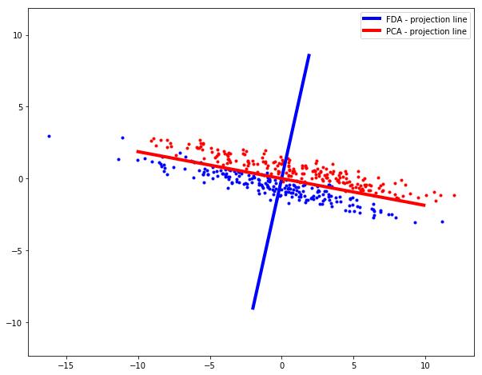

```python
data = np.vstack([x0, x1])
data = np.asmatrix(data)
num_data = data.shape[0]
S = 1 / (num_data - 1) * data.T * data

D, V = np.linalg.eig(S)
idx = np.argsort(-D)
D = D[idx]; V = V[:, idx]
h2 = V[1, 0] / V[0, 0]
xp2 = np.arange(-10, 10, 0.1)
yp2 = h2 * xp2

plt.figure(figsize = (10, 8))
plt.plot(x0[:,0],x0[:,1],'r.')
plt.plot(x1[:,0],x1[:,1],'b.')
plt.plot(xp, yp, 'b', linewidth = 4.0, label = 'FDA - projection line')
plt.plot(xp2, yp2, 'r', linewidth = 4.0, label = 'PCA - projection line')
plt.legend()
plt.axis('equal')
plt.show()
```

# Problem 3

1) What makes KNN algorithm operate much faster than other algorithms such as SVM or linear regression

2) In our class, we used the sklearn-embedded functions for k-NN. Here, you are asked to write your own function for KNN regressor.

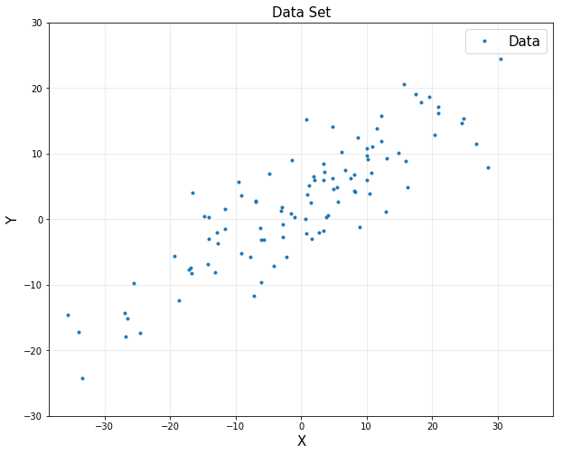

```python
import numpy as np
import matplotlib.pyplot as plt
%matplotlib inline

N = 100
w1 = 0.5
w0 = 2
x = np.random.normal(0, 15, N).reshape(-1,1)
y = w1*x + w0 + 5*np.random.normal(0, 1, N).reshape(-1,1)

plt.figure(figsize = (10, 8))
plt.title('Data Set', fontsize = 15)
plt.plot(x, y, '.', label = 'Data')
plt.xlabel('X', fontsize = 15)
plt.ylabel('Y', fontsize = 15)
plt.legend(fontsize = 15)
plt.axis('equal')
plt.axis([-40, 40, -30, 30])
plt.grid(alpha = 0.3)
plt.show()
```

```python
# here is your function for KNNReg
```

```python
# here is your code for plotting
```

3) In our class, we used the sklearn-embedded functions for k-NN. Here, you are asked to write your own function for KNN classification.

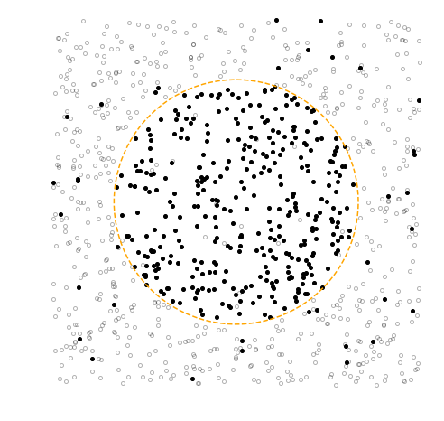

```python
m = 1000
X = -1.5 + 3*np.random.uniform(size = (m,2))

y = np.zeros([m,1])
for i in range(m):
    if np.linalg.norm(X[i,:], 2) <= 1:
        if np.random.uniform() < 0.05:
            y[i] = 0
        else:
            y[i] = 1
    else:
        if np.random.uniform() < 0.05:
            y[i] = 1
        else:
            y[i] = 0

C1 = np.where(y == 1)[0]
C0 = np.where(y == 0)[0]

theta = np.linspace(0, 2*np.pi, 100)

plt.figure(figsize = (8,8))
plt.plot(X[C1,0], X[C1,1], 'o', label = 'C1', markerfacecolor = "k", markeredgecolor = 'k', markersize = 4)
plt.plot(X[C0,0], X[C0,1], 'o', label = 'C0', markerfacecolor = "None", alpha = 0.3, markeredgecolor = 'k', markersize = 4)
plt.plot(np.cos(theta), np.sin(theta), '--', color = 'orange')
plt.axis([-1.5, 1.5, -1.5, 1.5])
plt.axis('equal')
plt.axis('off')
plt.show()
```

```python
# here is your function for KNNclf
```

```python
# here is your code for plotting
```

# Solution 3

1) What makes KNN algorithm operate much faster than other algorithms such as SVM or linear regression

KNN is a lazy algorithm that requires no training prior to making predictions. SVM or linear regression require training of data before it can make any predictions.

2) In our class, we used the sklearn-embedded functions for k-NN. Here, you are asked to write your own function for KNN regressor.

```python
import numpy as np
import matplotlib.pyplot as plt
from scipy import stats
from collections import Counter
%matplotlib inline
```

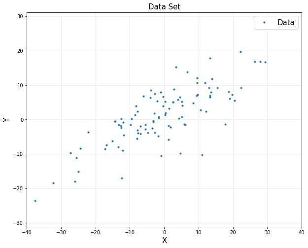

```python
N = 100
w1 = 0.5
w0 = 2
x = np.random.normal(0, 15, N).reshape(-1,1)
y = w1*x + w0 + 5*np.random.normal(0, 1, N).reshape(-1,1)

plt.figure(figsize = (10, 8))
plt.title('Data Set', fontsize = 15)
plt.plot(x, y, '.', label = 'Data')
plt.xlabel('X', fontsize = 15)
plt.ylabel('Y', fontsize = 15)
plt.legend(fontsize = 15)
plt.axis('equal')
plt.axis([-40, 40, -30, 30])
plt.grid(alpha = 0.3)
plt.show()
```

```python
data = np.hstack([x, y])
data
```

[output not shown]

[output cut: 45 more lines]

```
       [ 12.95674153,   9.16021462],
       [  0.21878028,   1.29846664],
       [  5.26622185,   3.99934972],
       [  1.3143752 ,  -5.78827405],
       [ 17.77453638,  -1.3627193 ],
       [ -3.19389105,  -0.32276012],
       [-14.26987451,  -0.54524471],
       [-12.30794615, -16.98369461],
       [ 11.04489387, -10.29936031],
       [-15.09445712,  -6.23549524],
       [ -0.99876744,   7.88893023],
       [ 13.57224288,   7.91842673],
       [ -2.88851624,   1.77502914],
       [-32.21772492, -18.4733648 ],
       [-12.5495829 ,  -2.35350277]])
```

```python
xp = np.linspace(-30, 30, 100).reshape(-1, 1)
yp = []

for i in range(len(xp)):

    dist_and_index = []

    for j, pts in enumerate(data):
        dist = 0
        dist = np.sqrt(np.sum((np.subtract(pts[:-1], xp[i]))**2))

        dist_and_index.append((dist, j))

    sort_dist_and_index = sorted(dist_and_index)

    knn_dist_and_index = sort_dist_and_index[:1]

    knn_labels = [data[j][1] for dist, j in knn_dist_and_index]

    knn_avg = np.mean(knn_labels)

    yp.append(knn_avg)
```

## K = 1

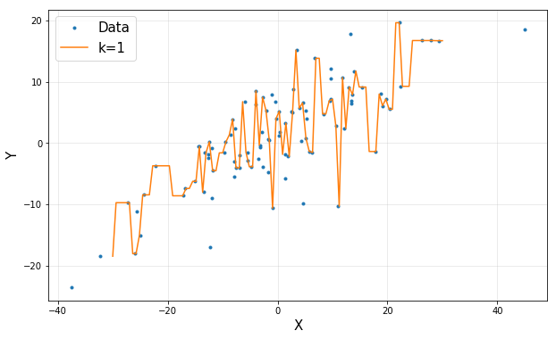

```python
plt.figure(figsize=(10, 6))
plt.plot(x, y, '.', label = 'Data')
plt.plot(xp, yp, label = 'k=1')
plt.legend(fontsize = 15)
plt.grid(alpha = 0.3)
plt.xlabel('X', fontsize = 15)
plt.ylabel('Y', fontsize = 15)
plt.show()
```

## K = 10

```python
xp = np.linspace(-30, 30, 100).reshape(-1, 1)
yp = []

for i in range(len(xp)):

    dist_and_index = []

    for j, pts in enumerate(data):
        dist = 0
        dist = np.sqrt(np.sum((np.subtract(pts[:-1], xp[i]))**2))

        dist_and_index.append((dist, j))

    sort_dist_and_index = sorted(dist_and_index)

    knn_dist_and_index = sort_dist_and_index[:10]

    knn_labels = [data[j][1] for dist, j in knn_dist_and_index]

    knn_avg = np.mean(knn_labels)

    yp.append(knn_avg)
```

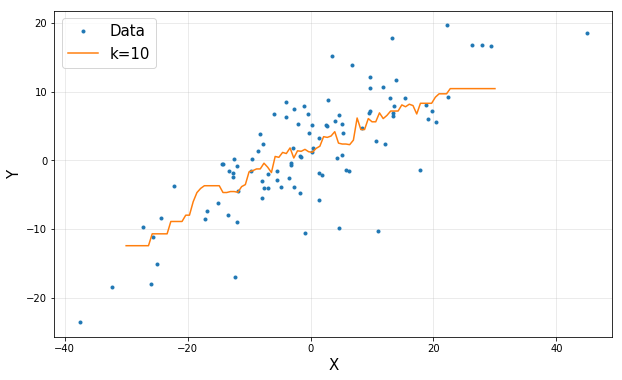

```python
plt.figure(figsize=(10, 6))
plt.plot(x, y, '.', label = 'Data')
plt.plot(xp, yp, label = 'k=10')
plt.legend(fontsize = 15)
plt.grid(alpha = 0.3)
plt.xlabel('X', fontsize = 15)
plt.ylabel('Y', fontsize = 15)
plt.show()
```

3) In our class, we used the sklearn-embedded functions for k-NN. Here, you are asked to write your own function for KNN classification.

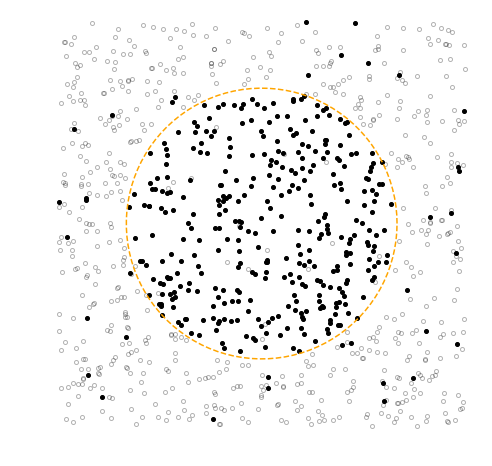

```python
m = 1000
X = -1.5 + 3*np.random.uniform(size = (m,2))

y = np.zeros([m,1])
for i in range(m):
    if np.linalg.norm(X[i,:], 2) <= 1:
        if np.random.uniform() < 0.05:
            y[i] = 0
        else:
            y[i] = 1
    else:
        if np.random.uniform() < 0.05:
            y[i] = 1
        else:
            y[i] = 0

C1 = np.where(y == 1)[0]
C0 = np.where(y == 0)[0]

theta = np.linspace(0, 2*np.pi, 100)

plt.figure(figsize = (8,8))
plt.plot(X[C1,0], X[C1,1], 'o', label = 'C1', markerfacecolor = "k", markeredgecolor = 'k', markersize = 4)
plt.plot(X[C0,0], X[C0,1], 'o', label = 'C0', markerfacecolor = "None", alpha = 0.3, markeredgecolor = 'k', markersize = 4)
plt.plot(np.cos(theta), np.sin(theta), '--', color = 'orange')
plt.axis([-1.5, 1.5, -1.5, 1.5])
plt.axis('equal')
plt.axis('off')
plt.show()
```

```python
res = 0.01
[X1gr, X2gr] = np.meshgrid(np.arange(-1.5,1.5,res), np.arange(-1.5,1.5,res))

Xp = np.hstack([X1gr.reshape(-1,1), X2gr.reshape(-1,1)])
```

```python
yp = []
for i in range(len(Xp)):
    t = np.sqrt(np.sum((np.subtract(Xp[i], X))**2, axis=1)).reshape(-1, 1)
    q = np.hstack([t, y])
    sort_p = sorted(q.tolist())
    knnCLF = sort_p[:1]
    knnCLF = np.array(knnCLF)
    knnCLF_label = knnCLF[:,1]
    yp.append(Counter(knnCLF_label).most_common(1)[0][0])
```

```python
yp = np.array(yp)
inCircle = np.where(yp == 1)[0]
```

## K = 1

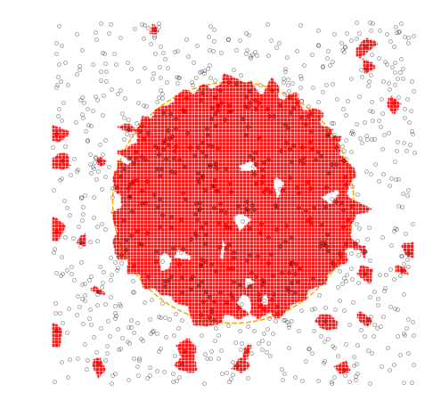

```python
plt.figure(figsize = (8, 8))
plt.plot(X[C1,0], X[C1,1], 'o', label = 'C1', markerfacecolor = "k", alpha = 0.5, markeredgecolor = 'k', markersize = 4)
plt.plot(X[C0,0], X[C0,1], 'o', label = 'C0', markerfacecolor = "None", alpha = 0.3, markeredgecolor='k', markersize = 4)
plt.plot(np.cos(theta), np.sin(theta), '--', color = 'orange')
plt.plot(Xp[inCircle][:,0], Xp[inCircle][:,1], 's', alpha = 0.5, color = 'r', markersize = 1)
plt.axis([-1.5, 1.5, -1.5, 1.5])
plt.axis('equal')
plt.axis('off')
plt.show()
```

## K = 10

```python
yp = []
for i in range(len(Xp)):
    t = np.sqrt(np.sum((np.subtract(Xp[i], X))**2, axis=1)).reshape(-1, 1)
    q = np.hstack([t, y])
    sort_p = sorted(q.tolist())
    knnCLF = sort_p[:10]
    knnCLF = np.array(knnCLF)
    knnCLF_label = knnCLF[:,1]
    yp.append(Counter(knnCLF_label).most_common(1)[0][0])
```

```python
yp = np.array(yp)
inCircle = np.where(yp == 1)[0]
```

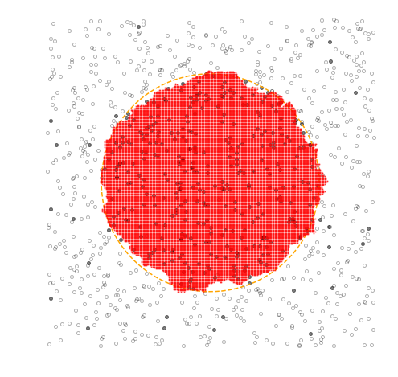

```python
plt.figure(figsize = (8, 8))
plt.plot(X[C1,0], X[C1,1], 'o', label = 'C1', markerfacecolor = "k", alpha = 0.5, markeredgecolor = 'k', markersize = 4)
plt.plot(X[C0,0], X[C0,1], 'o', label = 'C0', markerfacecolor = "None", alpha = 0.3, markeredgecolor='k', markersize = 4)
plt.plot(np.cos(theta), np.sin(theta), '--', color = 'orange')
plt.plot(Xp[inCircle][:,0], Xp[inCircle][:,1], 's', alpha = 0.5, color = 'r', markersize = 1)
plt.axis([-1.5, 1.5, -1.5, 1.5])
plt.axis('equal')
plt.axis('off')
plt.show()
```

# Problem 4

Look at the following training set for a decision tree that classifies names as either location or person names:

[figure not shown]

1) Which attribute is more useful, attribute 1 or attribute 2? Why?

2) As most pattern recognition methods, tree-based methods work best if proper features are selected. Discuss why preprocessing by PCA can be effective to find “important” axes with smaller maximum depth of the tree.

[figure not shown]

# Solution 4

1) Which attribute is more useful, attribute 1 or attribute 2? Why?

2) As most pattern recognition methods, tree-based methods work best if proper features are selected. Discuss why preprocessing by PCA can be effective to find “important” axes with smaller maximum depth of the tree.

[figure not shown]

The top figure shows that depending on the given features, a complicated decision tree may result while it can be better split along another direction. However if PCA is used to find the right direction for data splitting, the decision tree may be simpler as shown below.